# Stat 243 – another R Markdown doc

Sharon Velpula

April 07, 2022

1. Scatterplot with best fit overlain

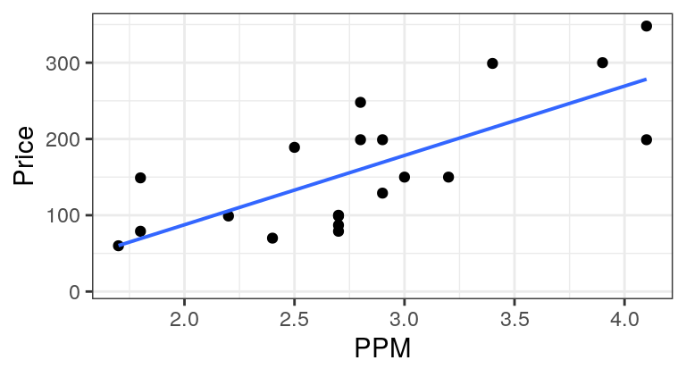

```r
gf_point(Price ~ PPM, data = InkjetPrinters) %>% gf_lm()
```

2. Equation of best fit line

```r
lm(Price ~ PPM, data = InkjetPrinters)
```

```
##
## Call:
## lm(formula = Price ~ PPM, data = InkjetPrinters)
##
## Coefficients:
## (Intercept)          PPM
##      -94.22        90.88
```

$$\widehat{Price} = 90.88\times\mbox{PPM} - 94.22$$

3. Diagnostic plots

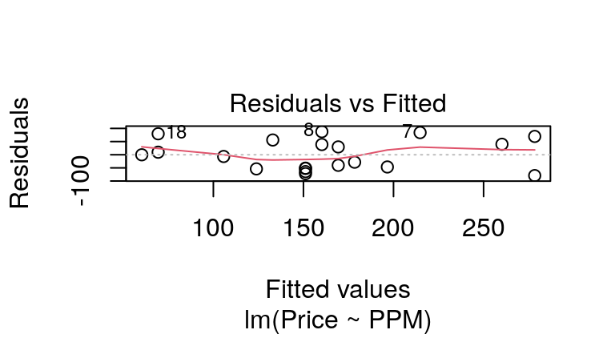

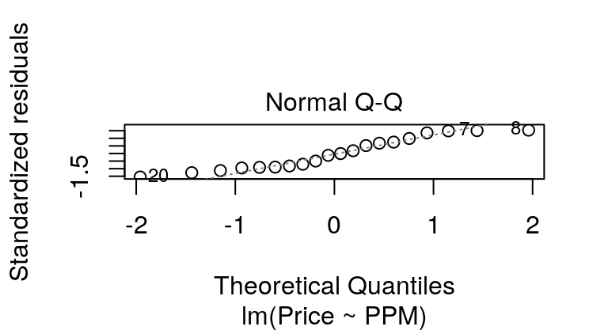

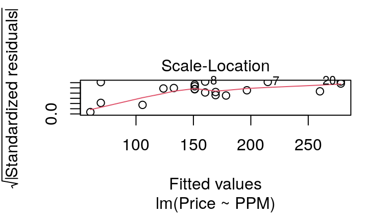

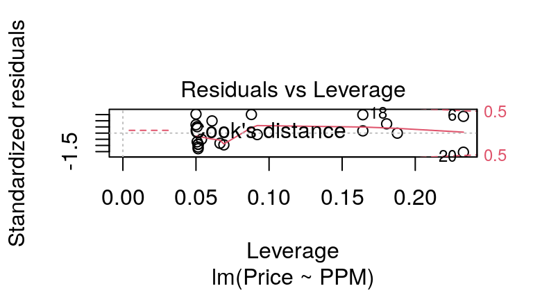

```r
lmResult <- lm(Price ~ PPM, data = InkjetPrinters)
plot(lm(Price ~ PPM, data = InkjetPrinters))
```

For the first diagnostic plot, we can see that the residuals are almost equally spread out which means that there aren’t any non-linear relationships.

For the second diagnostic plot, we can see that the residuals almost follow a straight line and appear to deviate at some points consistently. So, the residuals are normally distributed.

Therefore, SLM holds for this model.

4. Model Utility Test
   $$H_0: \beta_0 = 0$$
   $$H_a: \beta_1\ne 0$$

```r
summary(lm(Price ~ PPM, data = InkjetPrinters))
```

```
##
## Call:
## lm(formula = Price ~ PPM, data = InkjetPrinters)
##
## Residuals:
##    Min     1Q Median     3Q    Max
## -79.38 -51.40  -3.49  43.85  87.76
##
## Coefficients:
##             Estimate Std. Error t value Pr(>|t|)
## (Intercept)   -94.22      56.40  -1.671 0.112086
## PPM            90.88      19.49   4.663 0.000193 ***
## ---
## Signif. codes:  0 '***' 0.001 '**' 0.01 '*' 0.05 '.' 0.1 ' ' 1
##
## Residual standard error: 58.55 on 18 degrees of freedom
## Multiple R-squared:  0.5471, Adjusted R-squared:  0.522
## F-statistic: 21.75 on 1 and 18 DF,  p-value: 0.0001934
```

From what we can see, the test statistic is 4.663 and the p value is 0.0001934. Since the pvalue is very small, we can reject the null hypothesis and say that we have convincing evidence that PPM is an effective predictor of price in ink jet printers.

5. Coefficient of Determination

```r
summary(lm(Price ~ PPM, data = InkjetPrinters))
```

```
##
## Call:
## lm(formula = Price ~ PPM, data = InkjetPrinters)
##
## Residuals:
##    Min     1Q Median     3Q    Max
## -79.38 -51.40  -3.49  43.85  87.76
##
## Coefficients:
##             Estimate Std. Error t value Pr(>|t|)
## (Intercept)   -94.22      56.40  -1.671 0.112086
## PPM            90.88      19.49   4.663 0.000193 ***
## ---
## Signif. codes:  0 '***' 0.001 '**' 0.01 '*' 0.05 '.' 0.1 ' ' 1
##
## Residual standard error: 58.55 on 18 degrees of freedom
## Multiple R-squared:  0.5471, Adjusted R-squared:  0.522
## F-statistic: 21.75 on 1 and 18 DF,  p-value: 0.0001934
```

PPM explains 54.7% variability in Price of these 20 printers

6. Confidence Interval

```r
tstar <- qt(0.975, df = 18)
lm(Price ~ PPM, data = InkjetPrinters)$coefficients[2]+c(-1, 1)*tstar*19.49
```

```
## [1]  49.9311 131.8250
```

Since we rejected the null hypothesis, as expected, our pvalue of 0.0001934 is less than 0.05. Therefore the true slope lies between 49.9311 and 131.8250 and the slope given by our model also lies within this interval.